# SW_Hurdle_Models

Matt Webster

2026-07-28

The purpose of this RMarkdown is to implement hurdle models for SW ~ damPresence, & SW ~ damDensity (with and without geomorphic covariates)

4 models total.

```
WAIC suggests that models without geomorphic covariates (m1 & m3) perform better than those
with geomorphic covariates (m2 & m4), and that dam presence models perform better than their
dam density model counterparts. The WAIC metric is concerned with out-of-bag predictive
capabilities of a model set. Since we are not aiming for this to predict SW~beaver relationships
outside of our study, and the exclusion of geomorhpic covariates leads to the inflation of
estimated dam effects, I think it's best to gain inference from model 4, as long as parameters
are converging relatively well and making good sense.
```

**Hurdle HGLMM**

```
This analysis explores late summner surface water presence and area in relation to beaver dam presence,
& density.

All 4 models presented herein are constructed in a hurdle model framework with nested random slopes for
beaver dam effect to allow for stream, year, and sampleEvent to cause deviation from the
global mean beaver effect. Random intercepts are also included for stream, event, and
cluster ID.


Pt1: Surface water presence/absence; logistic regression

Pt2: Surface water amount, conditional on presence; log(Normal) regression

Uses log(SWA) for for 6 watersheds, 3 years, 4 sample periods (Aug-Sep) per year.
```

**Final Data:**

```
## 'data.frame':    2445 obs. of  26 variables:
##  $ X               : int  1 2 3 4 5 6 7 8 9 10 ...
##  $ clusterID_seq   : int  1 1 1 1 1 1 1 1 3 3 ...
##  $ window_type     : chr  "dammed" "dammed" "dammed" "dammed" ...
##  $ watershed       : chr  "WC" "WC" "WC" "WC" ...
##  $ year            : int  2019 2019 2019 2019 2019 2019 2019 2019 2019 2019 ...
##  $ catchment_km2   : num  1394 1394 1394 1394 1391 ...
##  $ TO              : num  34.2 34.2 34.2 34.2 35.7 ...
##  $ Nhat            : num  1.13 1.13 1.13 1.13 0 ...
##  $ t               : int  5 6 7 8 5 6 7 8 5 6 ...
##  $ surveyPeriod    : int  195 196 197 198 195 196 197 198 195 196 ...
##  $ SWA             : num  106.7 0 94.6 2382 66.7 ...
##  $ VA              : num  16274 17732 16901 4812 14708 ...
##  $ NDVI            : num  0.361 0.359 0.349 0.358 0.364 ...
##  $ riparian_area_m2: num  2678 2678 2678 2678 2766 ...
##  $ dam_km          : num  4.53 4.53 4.53 4.53 0 ...
##  $ clusterID_unique: chr  "2019.WC.1" "2019.WC.1" "2019.WC.1" "2019.WC.1" ...
##  $ clusterID_num   : int  16 16 16 16 16 16 16 16 34 34 ...
##  $ stream          : int  6 6 6 6 6 6 6 6 6 6 ...
##  $ sampleEvent     : int  1 2 3 4 1 2 3 4 1 2 ...
##  $ year_id         : int  1 1 1 1 1 1 1 1 1 1 ...
##  $ damPresence     : int  1 1 1 1 0 0 0 0 1 1 ...
##  $ sampleEvent_new : int  1 2 3 4 1 2 3 4 1 2 ...
##  $ logSWA          : num  4.68 0 4.56 7.78 4.21 ...
##  $ y               : int  1 0 1 1 1 1 1 1 1 1 ...
##  $ y_veg           : int  1 1 1 1 1 1 1 1 1 1 ...
##  $ dam_km_std      : num  0.499 0.499 0.499 0.499 -0.94 ...
```

For surface water models, data of interest include:

```
- y: surface water presence (0,1); response variable for logistic portion of hurdle model

- y2: log-transformed surface water area log(SWA[i]+1); response variable for HGLMM portion of hurdle model

- stream: index for random intercept on SWA and random slope on dam effect

- year: index for random slope on dam effect

- sampleEvent: index for random intercept on SWA and random slope on dam effect
  (nested within year; represents each 2 week sample period for SW layer )

- clusterID_seq: index for random intercept on SWA; represents sample pairing

- damPres: dam presence (0,1); fixed effect on SWA

- damDen: dams/km; z-standardized ("...$dam_km_std"); fixed effect on SWA

Only used in models 2 and 4:

- incis: channel incision: 1-(TO/90) (inverse of topographic openness); z-standardized; fixed effect on SWA

- RIPA: riparian area (m^2); z-standardized; fixed effect on SWA

- UDA: upstream drainage area (km ^2); z-standardized; fixed effect on SWA
```

**Overall Takeaways**

```
- Estimates may be notably inflated when geomorphic conditions are not taken into consideration (see m1 vs m2). The following regards models 2 and 4, which estimate the effect of damPresence or damDensity on surface water, conditional on geomorphic covariates:

- Dam presence has very little influence on surface water presence/absence. Surface water presence is instead
  driven by local geomorphic characteristics and random effects of stream/year/season.

- Likewise, 1 standard deviation increase in damDensity corresponds with a negligible increase in the odds of surface water presence.

- When surface water is present, presence of beaver dam(s) is associated with a 25% increase in surface water area from baseline conditions, although there is considerable variation among watersheds and time periods.

- Where surface water is present, 1 standard deviation increase in damDensity corresponds with a modest
  increase in surface water area (15%). Higher dam densities (3-4 SD increase) do notably
  increase surface water area relative to baseline conditions (upwards of ~50% increase in SWA).

- Of course there is A LOT of variation in these patterns by stream, year, and sampling event.
```

## SW ~ Dam Presence

**Model 1: SWA ~ DamPresence**

Effect of damPresence without geomorphic covariates

```
sink("HGLMM_Hurdle_m1_SW_damPres.jags")

cat("
model{
  # NEED priors and hyperpriors first so that downstream nodes can be estimated

  ##########################################################################

  # HYPERPRIORS FOR SW PRESENCE (1/2 Normal on SDs):

  sigma_zeta_stream  ~ dnorm(0,1) T(0,)
  tau_zeta_stream    <- pow(sigma_zeta_stream, -2)

  sigma_zeta_year    ~ dnorm(0,1) T(0,)
  tau_zeta_year      <- pow(sigma_zeta_year, -2)

  sigma_zeta_event   ~ dnorm(0,1) T(0,)
  tau_zeta_event     <- pow(sigma_zeta_event, -2)

  sigma_iota_stream  ~ dnorm(0,1) T(0,)
  tau_iota_stream    <- pow(sigma_iota_stream, -2)

  sigma_iota_year    ~ dnorm(0,1) T(0,)
  tau_iota_year      <- pow(sigma_iota_year, -2)

  sigma_iota_event   ~ dnorm(0,1) T(0,)
  tau_iota_event     <- pow(sigma_iota_event, -2)

  sigma_iota_cluster ~ dnorm(0,1) T(0,)
  tau_iota_cluster   <- pow(sigma_iota_cluster, -2)

  ##########################################################################
  # HYPERPRIORS FOR SW AMOUNT (1/2 Normal on SDs):

  sigma              ~ dnorm(0,1) T(0,)
  tau                <- pow(sigma, -2)

  sigma_beta_stream  ~ dnorm(0, 1) T(0,)
  tau_beta_stream    <- pow(sigma_beta_stream, -2)

  sigma_beta_year    ~ dnorm(0, 1) T(0,)
  tau_beta_year      <- pow(sigma_beta_year, -2)

  sigma_beta_event   ~ dnorm(0, 1) T(0,)
  tau_beta_event     <- pow(sigma_beta_event, -2)

  sigma_eta_stream   ~ dnorm(0, 1) T(0,)
  tau_eta_stream     <- pow(sigma_eta_stream, -2)

  sigma_eta_year     ~ dnorm(0, 1) T(0,)
  tau_eta_year       <- pow(sigma_eta_year, -2)

  sigma_eta_event    ~ dnorm(0, 1) T(0,)
  tau_eta_event      <- pow(sigma_eta_event, -2)

  sigma_eta_cluster  ~ dnorm(0, 1) T(0,)
  tau_eta_cluster    <- pow(sigma_eta_cluster, -2)

  ##########################################################################
  # FIXED EFFECT PRIORS:

  # Presence/absence:
  epsilon ~ dnorm(0,0.04)
  zeta_damPres ~ dnorm(0,0.04)

  # Amount:
  alpha ~ dnorm(3.57,0.04)    # SWA intercept within 5 SD of empirical mean
  beta_damPres ~ dnorm(0,0.04)

  ##########################################################################
  # RANDOM EFFECT PRIORS FOR SW PRESENCE:

  for(j in 1:n_stream){
    zeta_stream[j] ~ dnorm(0, tau_zeta_stream)
    iota_stream[j] ~ dnorm(0, tau_iota_stream)
  }

  for(yr in 1:n_year){
    zeta_year[yr] ~ dnorm(0, tau_zeta_year)
    iota_year[yr] ~ dnorm(0, tau_iota_year)
  }

  for(k in 1:n_event){
    zeta_event[k] ~ dnorm(zeta_year[event_year[k]], tau_zeta_event)
    iota_event[k] ~ dnorm(iota_year[event_year[k]], tau_iota_event)
  }

  for(c in 1:n_cluster){
    iota_cluster[c] ~ dnorm(0, tau_iota_cluster)
  }

  ##########################################################################
  # RANDOM EFFECT PRIORS FOR SW AMOUNT:

  for(j in 1:n_stream){
    beta_stream[j] ~ dnorm(0, tau_beta_stream)
    eta_stream[j]  ~ dnorm(0, tau_eta_stream)
  }

  for(yr in 1:n_year){
    beta_year[yr] ~ dnorm(0, tau_beta_year)
    eta_year[yr] ~ dnorm(0, tau_eta_year)
  }

  for(k in 1:n_event){
    beta_event[k] ~ dnorm(beta_year[event_year[k]], tau_beta_event)
    eta_event[k]  ~ dnorm(eta_year[event_year[k]], tau_eta_event)
  }

  for(c in 1:n_cluster){
    eta_cluster[c] ~ dnorm(0, tau_eta_cluster)
  }

  ##########################################################################
  # DETECTION PRIORS:

  for(k in 1:n_event){
  p_TP[k] ~ dnorm(0.76, pow(0.16,-2)) T(0,1)   # empirically derived recall
  p_FP[k] ~ dnorm(0.01, pow(0.005,-2)) T(0,1)  # empirically derived FPR
  }

  ##########################################################################
  # MAIN LOOP: PRESENCE, DETECTION, AMOUNT

  for(i in 1:N){

    # Presence/absence:
    z[i] ~ dbern(psi[i])

    logit(psi[i]) <- epsilon
                     + (zeta_damPres
                        + zeta_stream[stream[i]]
                        + zeta_year[year[i]]
                        + zeta_event[event[i]]) * damPres[i]
                     + iota_stream[stream[i]]
                     + iota_event[event[i]]
                     + iota_cluster[cluster[i]]

    # Detection:
    p_eff[i] <- z[i] * p_TP[event[i]] + (1-z[i]) * p_FP[event[i]]
    y[i]     ~ dbern(p_eff[i])

    # Amount:
    y2[i] ~ dnorm(mu[i], tau_eff[i])

    mu[i] <- z[i] *
              (alpha
                + (beta_damPres
                  + beta_stream[stream[i]]
                  + beta_year[year[i]]
                  + beta_event[event[i]]) * damPres[i]
                + eta_stream[stream[i]]
                + eta_event[event[i]]
                + eta_cluster[cluster[i]])

    tau_eff[i] <- z[i] * tau + (1 - z[i]) * 100

  ##########################################################################

  # Derived parameter for WAIC computation:

  loglik[i] <- logdensity.norm(y[i], mu[i], tau)
  }

}
", fill = TRUE)

sink()
```

```
## [1] "2026-08-19 10:58:02 MDT"
```

```
##
## Processing function input.......
##
## Done.
##
## Beginning parallel processing using 3 cores. Console output will be suppressed.
##
## Parallel processing completed.
##
## Calculating statistics.......
##
## Done.
```

```
## [1] "2026-08-19 12:16:31 MDT"
```

**Model 2: SWA ~ DamPresence + Geom.Covar.**

```
sink("HGLMM_Hurdle_m2_SW_damPres.jags")

cat("
model{
  # NEED priors and hyperpriors first so that downstream nodes can be estimated

  ##########################################################################

  # HYPERPRIORS FOR SW PRESENCE (1/2 Normal on SDs):

  sigma_zeta_stream  ~ dnorm(0,1) T(0,)
  tau_zeta_stream    <- pow(sigma_zeta_stream, -2)

  sigma_zeta_year    ~ dnorm(0,1) T(0,)
  tau_zeta_year      <- pow(sigma_zeta_year, -2)

  sigma_zeta_event   ~ dnorm(0,1) T(0,)
  tau_zeta_event     <- pow(sigma_zeta_event, -2)

  sigma_iota_stream  ~ dnorm(0,1) T(0,)
  tau_iota_stream    <- pow(sigma_iota_stream, -2)

  sigma_iota_year    ~ dnorm(0,1) T(0,)
  tau_iota_year      <- pow(sigma_iota_year, -2)

  sigma_iota_event   ~ dnorm(0,1) T(0,)
  tau_iota_event     <- pow(sigma_iota_event, -2)

  sigma_iota_cluster ~ dnorm(0,1) T(0,)
  tau_iota_cluster   <- pow(sigma_iota_cluster, -2)

  ##########################################################################
  # HYPERPRIORS FOR SW AMOUNT (1/2 Normal on SDs):

  sigma              ~ dnorm(0,1) T(0,)
  tau                <- pow(sigma, -2)

  sigma_beta_stream  ~ dnorm(0, 1) T(0,)
  tau_beta_stream    <- pow(sigma_beta_stream, -2)

  sigma_beta_year    ~ dnorm(0, 1) T(0,)
  tau_beta_year      <- pow(sigma_beta_year, -2)

  sigma_beta_event   ~ dnorm(0, 1) T(0,)
  tau_beta_event     <- pow(sigma_beta_event, -2)

  sigma_eta_stream   ~ dnorm(0, 1) T(0,)
  tau_eta_stream     <- pow(sigma_eta_stream, -2)

  sigma_eta_year     ~ dnorm(0,1) T(0,)
  tau_eta_year     <- pow(sigma_eta_year, -2)

  sigma_eta_event    ~ dnorm(0, 1) T(0,)
  tau_eta_event      <- pow(sigma_eta_event, -2)

  sigma_eta_cluster  ~ dnorm(0, 1) T(0,)
  tau_eta_cluster    <- pow(sigma_eta_cluster, -2)

  ##########################################################################
  # FIXED EFFECT PRIORS:

  # Presence/absence:
  epsilon ~ dnorm(0,0.04)
  zeta_damPres ~ dnorm(0,0.04)
  zeta_incis ~ dnorm(0,0.04)
  zeta_RIPA ~ dnorm(0,0.04)
  zeta_UDA ~ dnorm(0,0.04)

  # Amount:
  alpha ~ dnorm(3.57,0.04)   #anchor alpha within 5 SD of empirical mean logSWA
  beta_damPres ~ dnorm(0,0.04)
  beta_incis ~ dnorm(0,0.04)
  beta_RIPA ~ dnorm(0,0.04)
  beta_UDA ~ dnorm(0,0.04)

  ##########################################################################
  # RANDOM EFFECT PRIORS FOR SW PRESENCE:

  for(j in 1:n_stream){
    zeta_stream[j] ~ dnorm(0, tau_zeta_stream)
    iota_stream[j] ~ dnorm(0, tau_iota_stream)
  }

  for(yr in 1:n_year){
    zeta_year[yr] ~ dnorm(0, tau_zeta_year)
    iota_year[yr] ~ dnorm(0, tau_iota_year)
  }

  for(k in 1:n_event){
    zeta_event[k] ~ dnorm(zeta_year[event_year[k]], tau_zeta_event)
    iota_event[k] ~ dnorm(iota_year[event_year[k]], tau_iota_event)
  }

  for(c in 1:n_cluster){
    iota_cluster[c] ~ dnorm(0, tau_iota_cluster)
  }

  ##########################################################################
  # RANDOM EFFECT PRIORS FOR SW AMOUNT:

  for(j in 1:n_stream){
    beta_stream[j] ~ dnorm(0, tau_beta_stream)
    eta_stream[j]  ~ dnorm(0, tau_eta_stream)
  }

  for(yr in 1:n_year){
    beta_year[yr] ~ dnorm(0, tau_beta_year)
    eta_year[yr] ~ dnorm(0, tau_eta_year)
  }

  for(k in 1:n_event){
    beta_event[k] ~ dnorm(beta_year[event_year[k]], tau_beta_event)
    eta_event[k]  ~ dnorm(eta_year[event_year[k]], tau_eta_event)
  }

  for(c in 1:n_cluster){
    eta_cluster[c] ~ dnorm(0, tau_eta_cluster)
  }

  ##########################################################################
  # DETECTION PRIORS:

  for(k in 1:n_event){
  p_TP[k] ~ dnorm(0.76, pow(0.16,-2)) T(0,1)   # empirically derived recall
  p_FP[k] ~ dnorm(0.01, pow(0.005,-2)) T(0,1)  # empirically derived FPR
  }

  ##########################################################################
  # MAIN LOOP: PRESENCE, DETECTION, AMOUNT

  for(i in 1:N){

    # Presence/absence:
    z[i] ~ dbern(psi[i])

    logit(psi[i]) <- epsilon
                     + (zeta_damPres
                        + zeta_stream[stream[i]]
                        + zeta_year[year[i]]
                        + zeta_event[event[i]]) * damPres[i]
                     + zeta_incis * incis[i]
                     + zeta_RIPA * RIPA[i]
                     + zeta_UDA * UDA[i]
                     + iota_stream[stream[i]]
                     + iota_event[event[i]]
                     + iota_cluster[cluster[i]]

    # Detection:
    p_eff[i] <- z[i] * p_TP[event[i]] + (1-z[i]) * p_FP[event[i]]
    y[i]     ~ dbern(p_eff[i])

    # Amount:
    y2[i] ~ dnorm(mu[i], tau_eff[i])

    mu[i] <- z[i] *
              (alpha
                + (beta_damPres
                  + beta_stream[stream[i]]
                  + beta_year[year[i]]
                  + beta_event[event[i]]) * damPres[i]
                + beta_incis * incis[i]
                + beta_RIPA * RIPA[i]
                + beta_UDA * UDA[i]
                + eta_stream[stream[i]]
                + eta_event[event[i]]
                + eta_cluster[cluster[i]])

    tau_eff[i] <- z[i] * tau + (1 - z[i]) * 100

  ##########################################################################

  # Derived parameter for WAIC computation:

  loglik[i] <- logdensity.norm(y[i], mu[i], tau)
  }

}
", fill = TRUE)

sink()
```

## SW ~ Dam Density

**Hurdle HGLMM**

**MODEL 3: SW ~ damDensity (no Geom.Covar.)**

```
sink("HGLMM_Hurdle_m3_SW_damDen.jags")

cat("
model{
  # NEED priors and hyperpriors first so that downstream nodes can be estimated

  ##########################################################################

  # HYPERPRIORS FOR SW PRESENCE (1/2 Normal on SDs):

  sigma_zeta_stream  ~ dnorm(0,1) T(0,)
  tau_zeta_stream    <- pow(sigma_zeta_stream, -2)

  sigma_zeta_year    ~ dnorm(0,1) T(0,)
  tau_zeta_year      <- pow(sigma_zeta_year, -2)

  sigma_zeta_event   ~ dnorm(0,1) T(0,)
  tau_zeta_event     <- pow(sigma_zeta_event, -2)

  sigma_iota_stream  ~ dnorm(0,1) T(0,)
  tau_iota_stream    <- pow(sigma_iota_stream, -2)

  sigma_iota_year    ~ dnorm(0,1) T(0,)
  tau_iota_year      <- pow(sigma_iota_year, -2)

  sigma_iota_event   ~ dnorm(0,1) T(0,)
  tau_iota_event     <- pow(sigma_iota_event, -2)

  sigma_iota_cluster ~ dnorm(0,1) T(0,)
  tau_iota_cluster   <- pow(sigma_iota_cluster, -2)

  ##########################################################################
  # HYPERPRIORS FOR SW AMOUNT (1/2 Normal on SDs):

  sigma              ~ dnorm(0,1) T(0,)
  tau                <- pow(sigma, -2)

  sigma_beta_stream  ~ dnorm(0, 4) T(0,)
  tau_beta_stream    <- pow(sigma_beta_stream, -2)

  sigma_beta_year    ~ dnorm(0, 4) T(0,)
  tau_beta_year      <- pow(sigma_beta_year, -2)

  sigma_beta_event   ~ dnorm(0, 4) T(0,)
  tau_beta_event     <- pow(sigma_beta_event, -2)

  sigma_eta_stream   ~ dnorm(0, 1) T(0,)
  tau_eta_stream     <- pow(sigma_eta_stream, -2)

  sigma_eta_year     ~ dnorm(0, 1) T(0,)
  tau_eta_year       <- pow(sigma_eta_year, -2)

  sigma_eta_event    ~ dnorm(0, 1) T(0,)
  tau_eta_event      <- pow(sigma_eta_event, -2)

  sigma_eta_cluster  ~ dnorm(0, 1) T(0,)
  tau_eta_cluster    <- pow(sigma_eta_cluster, -2)

  ##########################################################################
  # FIXED EFFECT PRIORS:

  # Presence/absence:
  epsilon ~ dnorm(0,0.04)
  zeta_damDen ~ dnorm(0,0.04)

  # Amount:
  alpha ~ dnorm(3.57,0.04)  # within 5 SD of empirical mean logSWA
  beta_damDen ~ dnorm(0,0.04)

  ##########################################################################
  # RANDOM EFFECT PRIORS FOR SW PRESENCE:

  for(j in 1:n_stream){
    zeta_stream[j] ~ dnorm(0, tau_zeta_stream)
    iota_stream[j] ~ dnorm(0, tau_iota_stream)
  }

  for(yr in 1:n_year){
    zeta_year[yr] ~ dnorm(0, tau_zeta_year)
    iota_year[yr] ~ dnorm(0, tau_iota_year)
  }

  for(k in 1:n_event){
    zeta_event[k] ~ dnorm(zeta_year[event_year[k]], tau_zeta_event)
    iota_event[k] ~ dnorm(iota_year[event_year[k]], tau_iota_event)
  }

  for(c in 1:n_cluster){
    iota_cluster[c] ~ dnorm(0, tau_iota_cluster)
  }

  ##########################################################################
  # RANDOM EFFECT PRIORS FOR SW AMOUNT:

  for(j in 1:n_stream){
    beta_stream[j] ~ dnorm(0, tau_beta_stream)
    eta_stream[j]  ~ dnorm(0, tau_eta_stream)
  }

  for(yr in 1:n_year){
    beta_year[yr] ~ dnorm(0, tau_beta_year)
    eta_year[yr] ~ dnorm(0, tau_eta_year)
  }

  for(k in 1:n_event){
    beta_event[k] ~ dnorm(beta_year[event_year[k]], tau_beta_event)
    eta_event[k]  ~ dnorm(eta_year[event_year[k]], tau_eta_event)
  }

  for(c in 1:n_cluster){
    eta_cluster[c] ~ dnorm(0, tau_eta_cluster)
  }

  ##########################################################################
  # DETECTION PRIORS:

  for(k in 1:n_event){
  p_TP[k] ~ dnorm(0.76, pow(0.16,-2)) T(0,1)   # empirically derived recall
  p_FP[k] ~ dnorm(0.01, pow(0.005,-2)) T(0,1)  # empirically derived FPR
  }

  ##########################################################################
  # MAIN LOOP: PRESENCE, DETECTION, AMOUNT

  for(i in 1:N){

    # Presence/absence:
    z[i] ~ dbern(psi[i])

    logit(psi[i]) <- epsilon
                     + (zeta_damDen
                        + zeta_stream[stream[i]]
                        + zeta_year[year[i]]
                        + zeta_event[event[i]]) * damDen[i]
                     + iota_stream[stream[i]]
                     + iota_event[event[i]]
                     + iota_cluster[cluster[i]]

    # Detection:
    p_eff[i] <- z[i] * p_TP[event[i]] + (1-z[i]) * p_FP[event[i]]
    y[i]     ~ dbern(p_eff[i])

    # Amount:
    y2[i] ~ dnorm(mu[i], tau_eff[i])

    mu[i] <- z[i] *
              (alpha
                + (beta_damDen
                  + beta_stream[stream[i]]
                  + beta_year[year[i]]
                  + beta_event[event[i]]) * damDen[i]
                + eta_stream[stream[i]]
                + eta_event[event[i]]
                + eta_cluster[cluster[i]])

    tau_eff[i] <- z[i] * tau + (1 - z[i]) * 100

  ##########################################################################

  # Derived parameter for WAIC computation:

  loglik[i] <- logdensity.norm(y[i], mu[i], tau)
  }

}
", fill = TRUE)

sink()
```

**MODEL 4: SW ~ damDensity + Geom.Covar.**

```
sink("HGLMM_Hurdle_m4_SW_DamDen.jags")

cat("
model{
  # NEED priors and hyperpriors first so that downstream nodes can be estimated

  ##########################################################################

  # HYPERPRIORS FOR SW PRESENCE (1/2 Normal on SDs):

  sigma_zeta_stream  ~ dnorm(0,1) T(0,)
  tau_zeta_stream    <- pow(sigma_zeta_stream, -2)

  sigma_zeta_year    ~ dnorm(0,1) T(0,)
  tau_zeta_year      <- pow(sigma_zeta_year, -2)

  sigma_zeta_event   ~ dnorm(0,1) T(0,)
  tau_zeta_event     <- pow(sigma_zeta_event, -2)

  sigma_iota_stream  ~ dnorm(0,1) T(0,)
  tau_iota_stream    <- pow(sigma_iota_stream, -2)

  sigma_iota_year    ~ dnorm(0,1) T(0,)
  tau_iota_year      <- pow(sigma_iota_year, -2)

  sigma_iota_event   ~ dnorm(0,1) T(0,)
  tau_iota_event     <- pow(sigma_iota_event, -2)

  sigma_iota_cluster ~ dnorm(0,1) T(0,)
  tau_iota_cluster   <- pow(sigma_iota_cluster, -2)

  ##########################################################################
  # HYPERPRIORS FOR SW AMOUNT (1/2 Normal on SDs):

  sigma              ~ dnorm(0,1) T(0,)
  tau                <- pow(sigma, -2)

  sigma_beta_stream  ~ dnorm(0, 4) T(0,)
  tau_beta_stream    <- pow(sigma_beta_stream, -2)

  sigma_beta_year    ~ dnorm(0, 4) T(0,)
  tau_beta_year      <- pow(sigma_beta_year, -2)

  sigma_beta_event   ~ dnorm(0, 4) T(0,)
  tau_beta_event     <- pow(sigma_beta_event, -2)

  sigma_eta_stream   ~ dnorm(0, 1) T(0,)
  tau_eta_stream     <- pow(sigma_eta_stream, -2)

  sigma_eta_year     ~ dnorm(0, 1) T(0,)
  tau_eta_year       <- pow(sigma_eta_year, -2)

  sigma_eta_event    ~ dnorm(0, 1) T(0,)
  tau_eta_event      <- pow(sigma_eta_event, -2)

  sigma_eta_cluster  ~ dnorm(0, 1) T(0,)
  tau_eta_cluster    <- pow(sigma_eta_cluster, -2)

  ##########################################################################
  # FIXED EFFECT PRIORS:

  # Presence/absence:
  epsilon ~ dnorm(0,0.04)
  zeta_damDen ~ dnorm(0,0.04)
  zeta_incis ~ dnorm(0,0.04)
  zeta_RIPA ~ dnorm(0,0.04)
  zeta_UDA ~ dnorm(0,0.04)

  # Amount:
  alpha ~ dnorm(3.57,0.04)     # within 5 SD of empirical mean logSWA
  beta_damDen ~ dnorm(0,0.04)
  beta_incis ~ dnorm(0,0.04)
  beta_RIPA ~ dnorm(0,0.04)
  beta_UDA ~ dnorm(0,0.04)

  ##########################################################################
  # RANDOM EFFECT PRIORS FOR SW PRESENCE:

  for(j in 1:n_stream){
    zeta_stream[j] ~ dnorm(0, tau_zeta_stream)
    iota_stream[j] ~ dnorm(0, tau_iota_stream)
  }

  for(yr in 1:n_year){
    zeta_year[yr] ~ dnorm(0, tau_zeta_year)
    iota_year[yr] ~ dnorm(0, tau_iota_year)
  }

  for(k in 1:n_event){
    zeta_event[k] ~ dnorm(zeta_year[event_year[k]], tau_zeta_event)
    iota_event[k] ~ dnorm(iota_year[event_year[k]], tau_iota_event)
  }

  for(c in 1:n_cluster){
    iota_cluster[c] ~ dnorm(0, tau_iota_cluster)
  }

  ##########################################################################
  # RANDOM EFFECT PRIORS FOR SW AMOUNT:

  for(j in 1:n_stream){
    beta_stream[j] ~ dnorm(0, tau_beta_stream)
    eta_stream[j]  ~ dnorm(0, tau_eta_stream)
  }

  for(yr in 1:n_year){
    beta_year[yr] ~ dnorm(0, tau_beta_year)
    eta_year[yr] ~ dnorm(0, tau_eta_year)
  }

  for(k in 1:n_event){
    beta_event[k] ~ dnorm(beta_year[event_year[k]], tau_beta_event)
    eta_event[k]  ~ dnorm(eta_year[event_year[k]], tau_eta_event)
  }

  for(c in 1:n_cluster){
    eta_cluster[c] ~ dnorm(0, tau_eta_cluster)
  }

  ##########################################################################
  # DETECTION PRIORS:

  for(k in 1:n_event){
  p_TP[k] ~ dnorm(0.76, pow(0.16,-2)) T(0,1)   # empirically derived recall
  p_FP[k] ~ dnorm(0.01, pow(0.005,-2)) T(0,1)  # empirically derived FPR
  }

  ##########################################################################
  # MAIN LOOP: PRESENCE, DETECTION, AMOUNT

  for(i in 1:N){

    # Presence/absence:
    z[i] ~ dbern(psi[i])

    logit(psi[i]) <- epsilon
                     + (zeta_damDen
                        + zeta_stream[stream[i]]
                        + zeta_year[year[i]]
                        + zeta_event[event[i]]) * damDen[i]
                     + zeta_incis * incis[i]
                     + zeta_RIPA * RIPA[i]
                     + zeta_UDA * UDA[i]
                     + iota_stream[stream[i]]
                     + iota_event[event[i]]
                     + iota_cluster[cluster[i]]

    # Detection:
    p_eff[i] <- z[i] * p_TP[event[i]] + (1-z[i]) * p_FP[event[i]]
    y[i]     ~ dbern(p_eff[i])

    # Amount:
    y2[i] ~ dnorm(mu[i], tau_eff[i])

    mu[i] <- z[i] *
              (alpha
                + (beta_damDen
                  + beta_stream[stream[i]]
                  + beta_year[year[i]]
                  + beta_event[event[i]]) * damDen[i]
                + beta_incis * incis[i]
                + beta_RIPA * RIPA[i]
                + beta_UDA * UDA[i]
                + eta_stream[stream[i]]
                + eta_event[event[i]]
                + eta_cluster[cluster[i]])

    tau_eff[i] <- z[i] * tau + (1 - z[i]) * 100


  ##########################################################################

  # Derived parameter for WAIC computation:

  loglik[i] <- logdensity.norm(y[i], mu[i], tau)
  }

}
", fill = TRUE)

sink()
```

```
## [1] "2026-08-19 15:51:05 MDT"
```

```
##
## Processing function input.......
##
## Done.
##
## Beginning parallel processing using 3 cores. Console output will be suppressed.
##
## Parallel processing completed.
##
## Calculating statistics.......
##
## Done.
```

```
## [1] "2026-08-19 16:32:41 MDT"
```

## DIAGNOSTICS:

**Assess “Chain health” Rhat + ESS:**

```
## Potential scale reduction factors:
##
##                    Point est. Upper C.I.
## epsilon                  1.00       1.00
## alpha                    1.00       1.00
## zeta_damDen              1.02       1.02
## beta_damDen              1.01       1.01
## zeta_incis               1.01       1.04
## beta_incis               1.00       1.00
## zeta_RIPA                1.00       1.00
## beta_RIPA                1.00       1.00
## zeta_UDA                 1.00       1.01
## beta_UDA                 1.00       1.00
## sigma                    1.00       1.00
## sigma_zeta_stream        1.00       1.00
## sigma_iota_cluster       1.10       1.33
## p_TP[1]                  1.00       1.00
## p_FP[1]                  1.00       1.00
```

```
##            epsilon              alpha        zeta_damDen        beta_damDen
##         24484.0406          8019.1458           730.6272          1413.7049
##         zeta_incis         beta_incis          zeta_RIPA          beta_RIPA
##         11780.3515         42638.3891         41135.8577         45878.6399
##           zeta_UDA           beta_UDA              sigma  sigma_zeta_stream
##         14843.9217         43796.5658         45262.4656          8979.6046
## sigma_iota_cluster            p_TP[1]            p_FP[1]
##          4522.9965         34323.1474         45000.0000
```

```
Rhat & Effective Sample Size:

Acceptable. Most Rhats = 1. zeta_damDen is slow to converge, and having trouble
being estimated. It is a REALLY small effect, with LOTS of variation across grouping
random variables, so it's hard for the MCMC chains to converge on a single estimate.
```

**Check traceplots** for critical parameters:

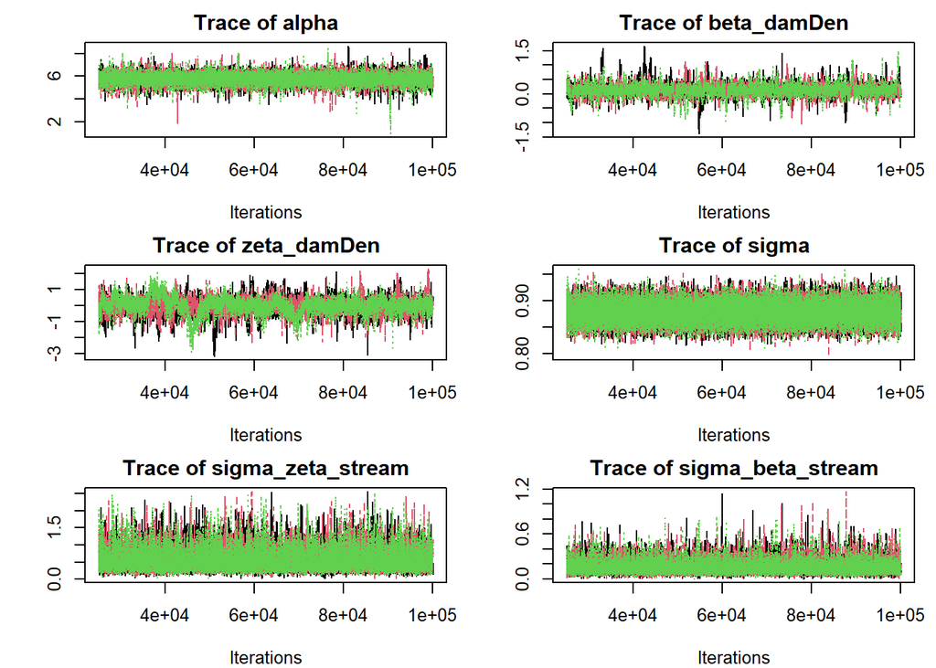

```
Traceplots all look okay, again see zeta_damDen. Could increase iterations, or tighten prior...?

Matt: Closely read Ogle and Barber (2020) Ensuring identifiability in hierarchical mixed effects Bayesian models

for potential ways to improve/considerations re: identifiability...
```

**Posterior predictive plots:**

Predicted Psi vs observed SW presence

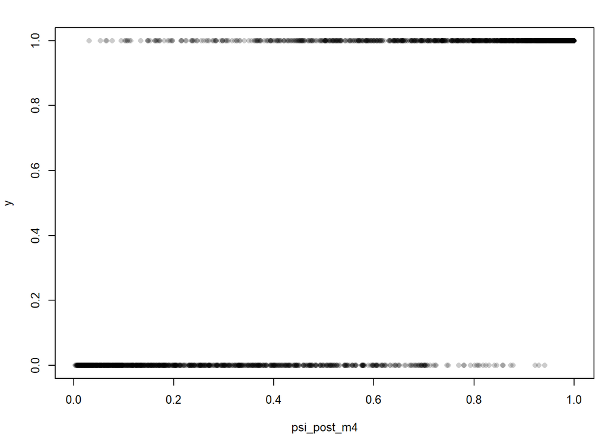

Predicted SW vs observed SW

Goal is 1:1 (ish)

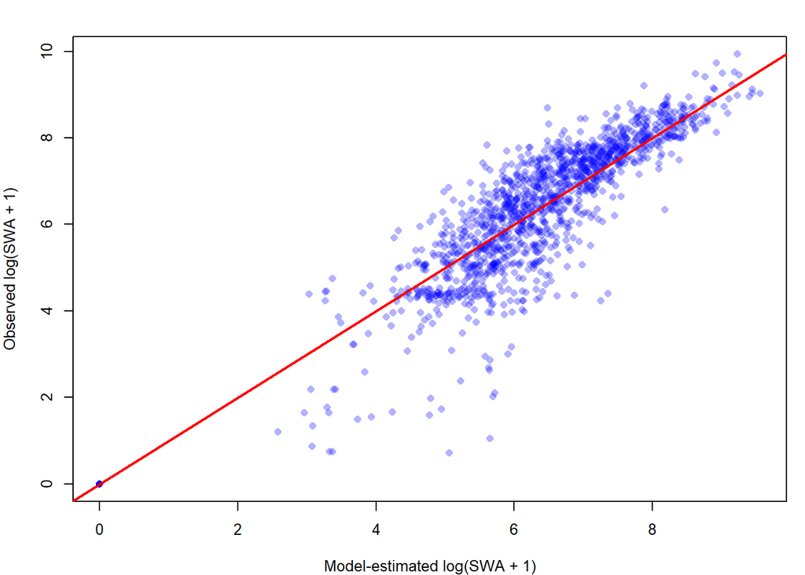

Slope:

```
## m4_mu_SW_post
##       1.00681
```

```
1.006 suggests model fits the data well, though slightly underestimates variance in
logSWA at lower values.
```

**Random effects shrinkage:**

Goal is centered around 0(ish)

. iota_stream; stream random intercept for SW presence . eta_stream; stream random intercept for SWA . zeta_stream; stream random slope for damDen effect on SW presence . beta_stream; stream random slope for damDen effect on SWA . zeta_event; event random slope for damDen effect on SW presence . beta_event; event random slope for damDen effect on SWA

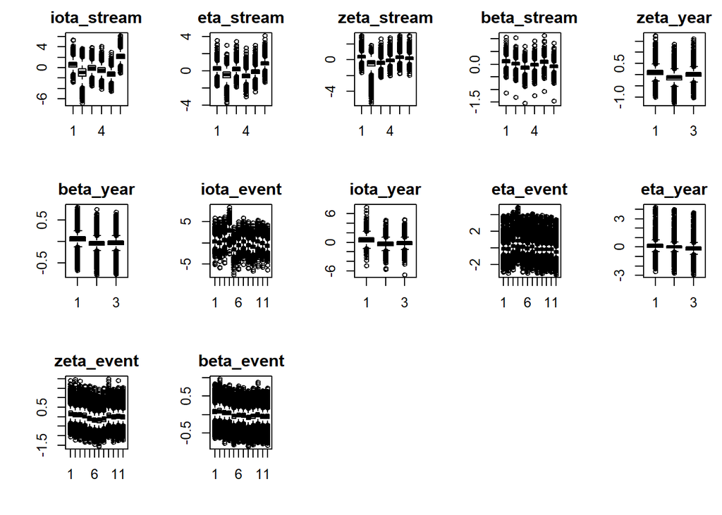

```
These all seem reasonable.
```

**Prior-posterior overlap:**

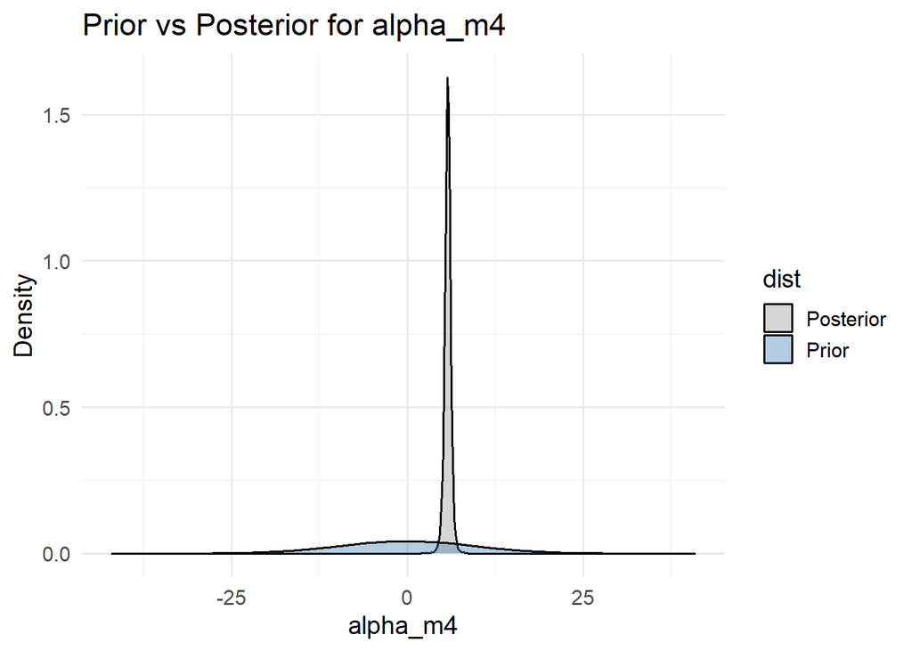

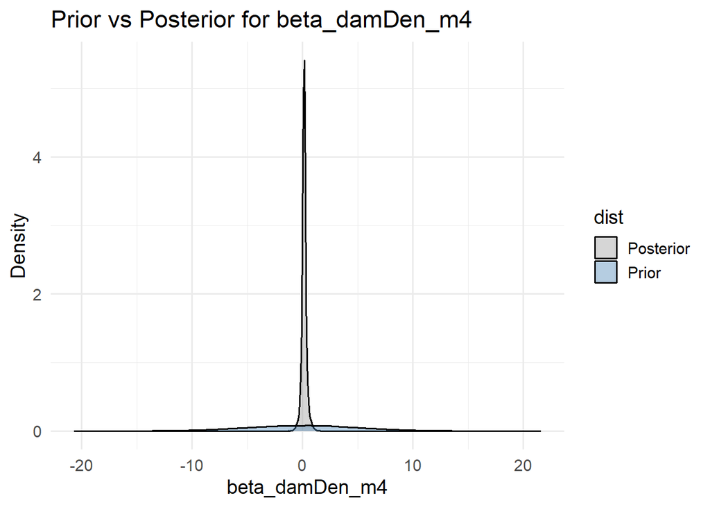

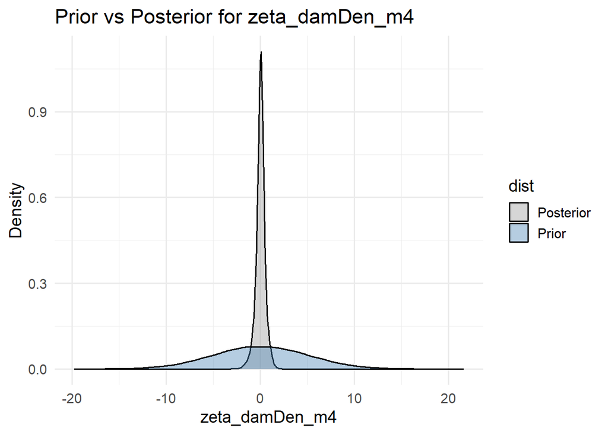

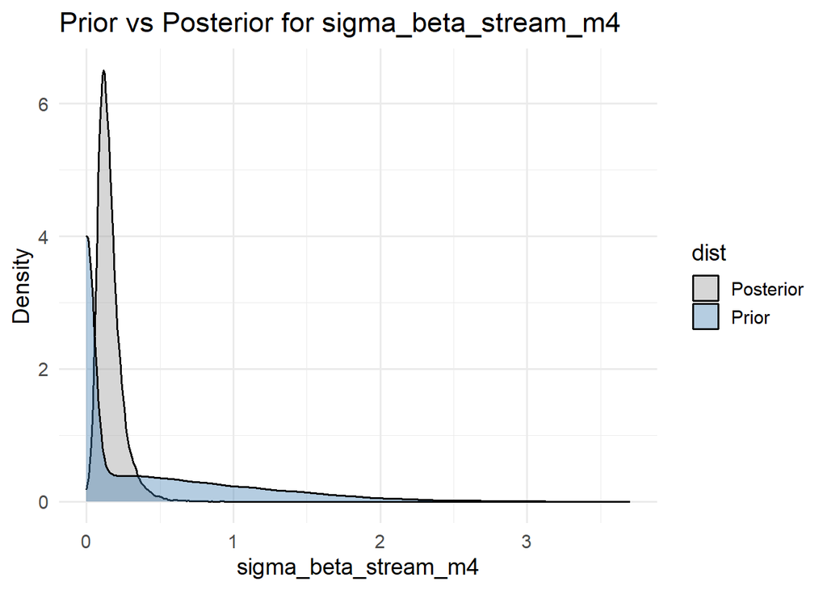

```
PPOs look good pretty good. Data seems to be driving posterior estimates.
```

**Posterior Estimates**

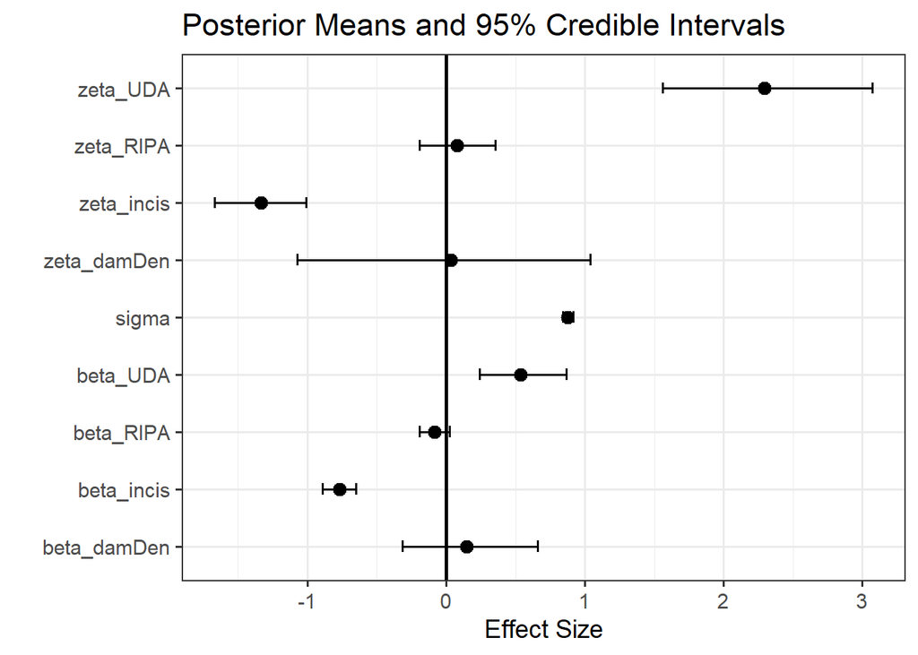

**Estimated effects of dam density**

**Effect of 1 SD increase in dam density on surface water (SW) presence:**

```
##     Min.  1st Qu.   Median     Mean  3rd Qu.     Max.
## -3.13915 -0.21358  0.05456  0.03439  0.30422  2.31268
```

```
## [1] 1.034985
```

```
## [1] "Change in Psi(SW) with 1 SD increase in dam density"
```

```
## [1] 0.005484031
```

```
For a typical stream at mean covariate conditions, a 1 SD increase dam density is associated
with basically no change in the probability of surface water presence (+0.03 change on
log-odds scale corresponds to an increase of 0.5% on the probability scale).

NOTE: HEAVILY OVERLAPS 0. This indicates that there is no consistent influence of damDensity
across grouping variables (stream,year,event) in the data. Some settings see strong positive
influence of dams, some settings see strong negative influence of dams, most see a weak or
negligible influence of dams.
```

**Effect of 1 SD increase in dam density on SW amount:**

```
##     Min.  1st Qu.   Median     Mean  3rd Qu.     Max.
## -1.37966  0.04094  0.14274  0.14736  0.24481  1.65954
```

```
## [1] 1.158774
```

```
## [1] "SWA change with 1 SD increase in dam density"
```

```
## [1] 52.1917
```

```
A 1 SD increase dam density is associated with ~ 14-15% increase in log(SWA+1),
which, for a "typical" stream under mean geomorphic covariate conditions, corresponds
to an increase of ~ 50 m^2 of SW.

Note: at the high end of dam density, a typical stream at mean covariate conditions
would see an estimated increase of ~150-300 m^2 of SW.

NOTE: see above note re: 0 overlap and consistency of damDensity effect across the data
```

**Estimated effects of geomorphic covariates**

**Effect of 1 SD increase in incision on surface water (SW) presence:**

```
##    Min. 1st Qu.  Median    Mean 3rd Qu.    Max.
## -2.0247 -1.4449 -1.3295 -1.3323 -1.2173 -0.6461
```

```
## [1] 0.2638826
```

```
## [1] "Change in Psi(SW) with 1 SD increase in incision"
```

```
## [1] -0.3182757
```

[output not shown]

**Effect of 1 SD increase in incision on SW amount:**

```
##    Min. 1st Qu.  Median    Mean 3rd Qu.    Max.
## -1.0499 -0.8116 -0.7691 -0.7696 -0.7272 -0.4875
```

```
## [1] 0.4632087
```

```
## [1] "SWA change with 1 SD increase in incision"
```

```
## [1] -173.1788
```

[output not shown]

**Effect of 1 SD increase in riparian area on surface water (SW) presence:**

```
##     Min.  1st Qu.   Median     Mean  3rd Qu.     Max.
## -0.49912 -0.01419  0.07921  0.07960  0.17299  0.67982
```

```
## [1] 1.082855
```

```
## [1] "Change in Psi(SW) with 1 SD increase in riparian area"
```

```
## [1] 0.01737663
```

```
A 1 SD increase in riparian area (corresponds with an increase of ~10366 m^2
on the raw RIPA scale), is associated with a 8% increase in ODDS, which corresponds
with a ~1% increase in the PROBABILITY of SW presence.

NOTE: HEAVY overlap of 0.
```

**Effect of 1 SD increase in riparian area on SW amount:**

```
##     Min.  1st Qu.   Median     Mean  3rd Qu.     Max.
## -0.31779 -0.11901 -0.08165 -0.08197 -0.04476  0.15536
```

```
## [1] 0.9212977
```

```
## [1] "SWA change with 1 SD increase in riparian area"
```

```
## [1] -24.79505
```

```
A 1 SD increase in RIPA is associated with a ~ 8% decrease in log(SWA). Meager negative
effect, slightly overlapping 0. This corresponds with a decrease of ~23 m^2
(for typical stream under mean conditions).
```

**Effect of 1 SD increase in upstream drainage area (UDA) on SW presence:**

```
##    Min. 1st Qu.  Median    Mean 3rd Qu.    Max.
##  0.8286  2.0295  2.2813  2.2915  2.5446  4.0791
```

```
## [1] 9.890068
```

```
## [1] "Change in Psi(SW) with 1 SD increase in drainage area"
```

```
## [1] 0.2802222
```

[output not shown]

**Effect of 1 SD increase in Upstream Drainage Area on SW amount:**

```
##    Min. 1st Qu.  Median    Mean 3rd Qu.    Max.
## -0.1076  0.4294  0.5315  0.5375  0.6401  1.2995
```

```
## [1] 1.711672
```

```
## [1] "SWA change with 1 SD increase in drainage area"
```

```
## [1] 229.8072
```

[output not shown]

**Marginal effect** of dam Density on surface water presence, given geomorphic context

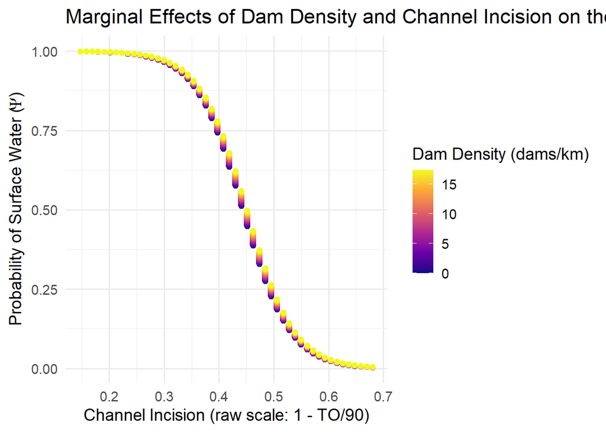

[figure not shown]

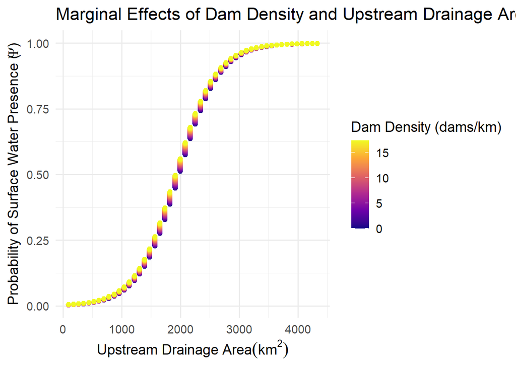

**Partial dependence plots**

Constrain PDP to empirical ranges for SWA and target covariates

Dam density effect across target covariate range; all other covariates held at median conditions

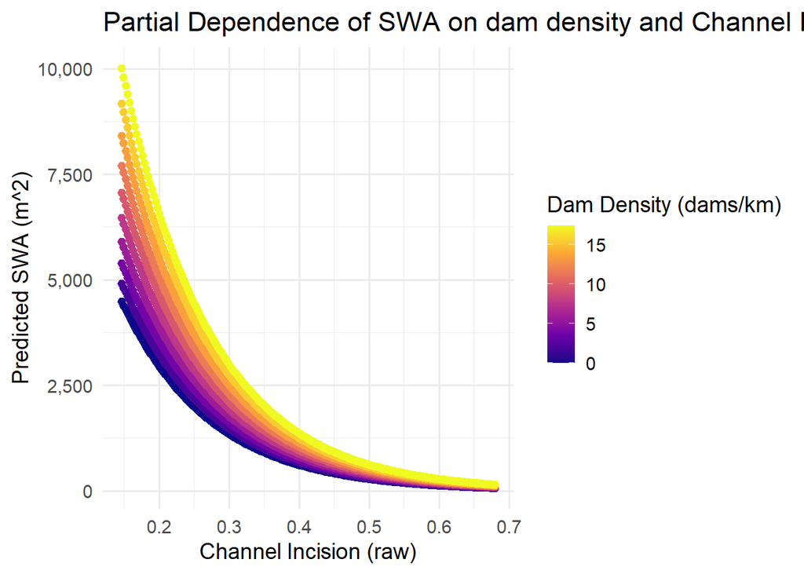

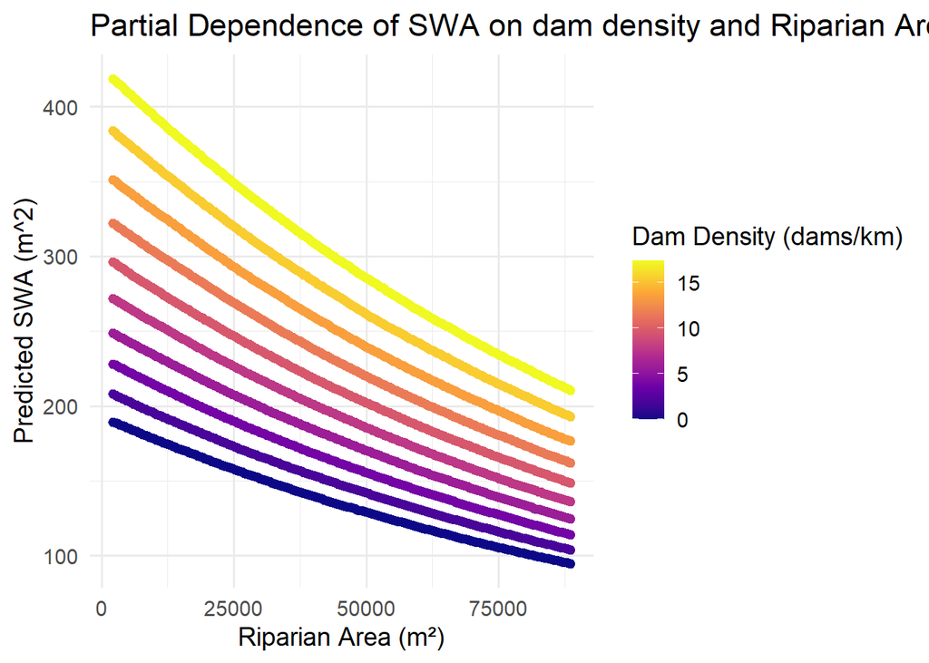

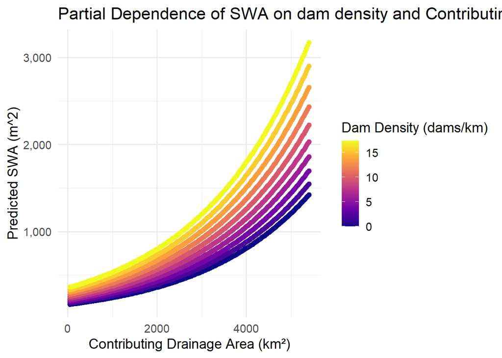

**Change in SWA across damDensity by stream and sampleEvent**

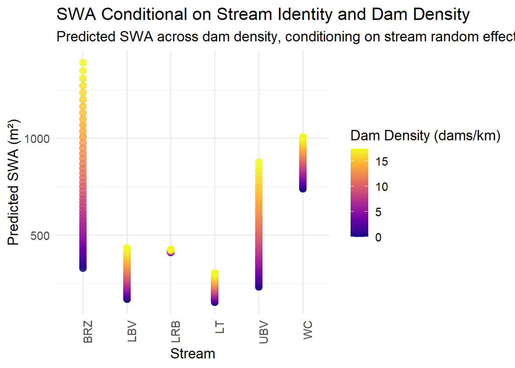

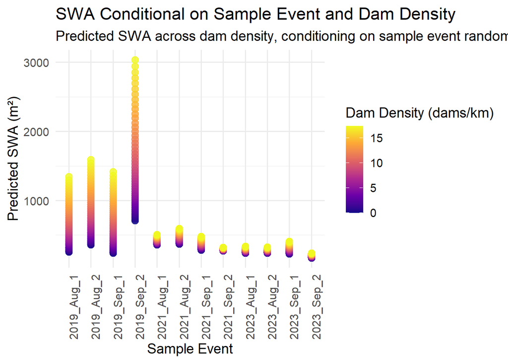

**Model Comparison**

```
## # A tibble: 4 × 2
##   model   WAIC
##   <chr>  <dbl>
## 1 m1    61217.
## 2 m3    62285.
## 3 m2    70554.
## 4 m4    70727.
```